# FF_Lab_5

# **LAB 5**

# **Part One: Data Exploration**

```python
import numpy as np
import pandas as pd
```

```python
health_insur = pd.read_csv("https://www.dropbox.com/s/bocjjyo1ehr5auz/insurance_costs_1.csv?dl=1")
```

### Summaries of data

```python
health_insur.describe()
```

|  | age | bmi | charges |
| --- | --- | --- | --- |
| count | 431.00 | 431.00 | 431.00 |
| mean | 37.96 | 30.77 | 12297.10 |
| std | 16.36 | 6.11 | 11876.53 |
| min | 18.00 | 15.96 | 1131.51 |
| 25% | 22.00 | 26.36 | 2710.44 |
| 50% | 34.00 | 30.59 | 9866.30 |
| 75% | 55.00 | 35.27 | 14510.87 |
| max | 64.00 | 49.06 | 55135.40 |

```python
health_insur[['sex']].apply(pd.Series.value_counts)
```

|  | sex |
| --- | --- |
| female | 225 |
| male | 206 |

```python
health_insur[['region']].apply(pd.Series.value_counts)
```

|  | region |
| --- | --- |
| southeast | 125 |
| northeast | 108 |
| southwest | 103 |
| northwest | 95 |

```python
health_insur[['smoker']].apply(pd.Series.value_counts)
```

|  | smoker |
| --- | --- |
| no | 344 |
| yes | 87 |

### Plots about the data

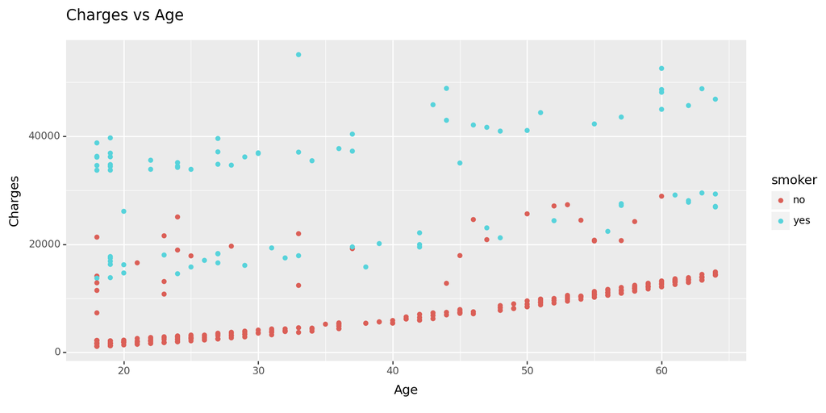

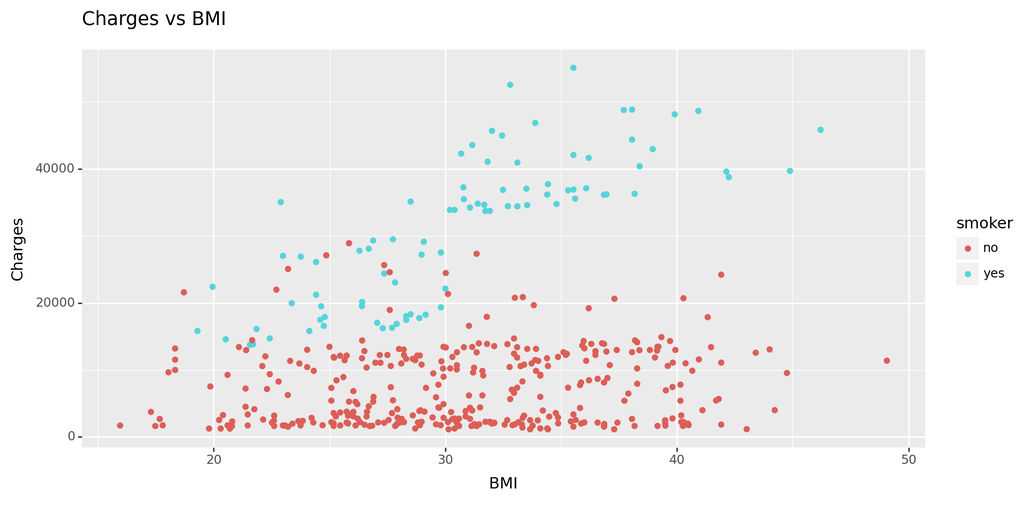

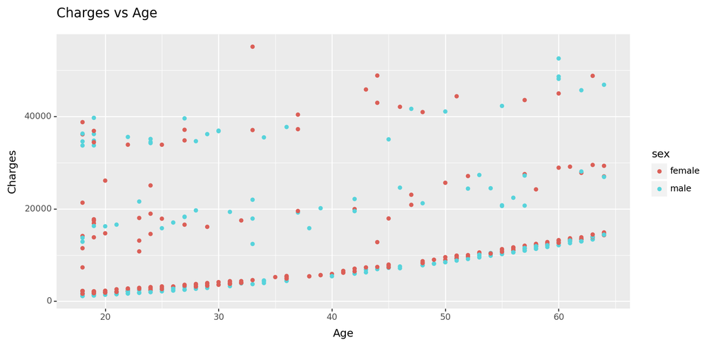

```
(<Figure Size: (1000 x 500)>,
 <Figure Size: (1000 x 500)>,
 <Figure Size: (1000 x 500)>)
```

```python
from plotnine import ggplot, aes, geom_bar, geom_boxplot, geom_histogram, theme, geom_point, geom_line, labs


plot1 = (ggplot(health_insur, aes(x='age', y='charges', color = 'smoker'))
         + geom_point()
         + theme(figure_size=(10, 5))
         + labs(title="Charges vs Age", x="Age", y="Charges"))


plot2 = (ggplot(health_insur, aes(x='bmi', y='charges', color = 'smoker'))
         + geom_point()
         + theme(figure_size=(10, 5))
         + labs(title="Charges vs BMI", x="BMI", y="Charges"))


plot3 = (ggplot(health_insur, aes(x='age', y='charges', color = 'sex'))
         + geom_point()
         + theme(figure_size=(10, 5))
         + labs(title="Charges vs Age", x="Age", y="Charges"))


plot1, plot2, plot3
```

### Discussion of plots

On the plots above we can see a relation between age and the insurance costs, the older we get the more expensive it gets. We can also see that insurance costs are generally higher for smokers vs non-smokers.

Furthermore, we can see that bmi doesn’t impact non smokers a lot as it seems to be pretty flat, but for smokers, the higher the bmi, the higher the charges.

On the last plot we can guess sex most likely doesn’t really play a role in insurance costs as we see no clear difference between the males and females. We can further analyze sex and region by having a boxplot of them to see if there are any clear differences.

# **Part Two: Simple Linear Models**

## 1. Construct a simple linear model to predict the insurance charges from the beneficiary’s age. Discuss the model fit, and interpret the coefficient estimates.

```python
from sklearn.pipeline import Pipeline
from sklearn.preprocessing import StandardScaler, OneHotEncoder, PolynomialFeatures
from sklearn.linear_model import LinearRegression
from sklearn.model_selection import train_test_split
from sklearn.metrics import r2_score, mean_squared_error
from sklearn.compose import ColumnTransformer
from sklearn.preprocessing import FunctionTransformer
```

```python
## splitting x_train and X_test for the only time
X = health_insur.drop('charges', axis=1)
y = health_insur['charges']

X_train, X_test, y_train, y_test = train_test_split(X, y, test_size=0.25)

def return_same(X):
  return X

pass_variable = FunctionTransformer(return_same)
```

```python
# creating collum tranformer to use only variable age
ct = ColumnTransformer(
  [('untouched_exp_var', pass_variable, ['age'])
  ],
  remainder = "drop"
)

#creating pipeline
lr_pipe = Pipeline(
    [('preprocessing', ct),
        ('linear_reg', LinearRegression())]
)

#fitting it
fitted_lr_pipe = lr_pipe.fit(X_train,y_train)


y_preds = fitted_lr_pipe.predict(X_test)

r2_part11 = r2_score(y_test, y_preds)
mse_part11 = mean_squared_error(y_test, y_preds)

coeff = fitted_lr_pipe.named_steps['linear_reg'].coef_

r2_part11, mse_part11, coeff
```

```
(0.11288430494799195, 140116956.47691017, array([214.60773371]))
```

if we are trying to predict the insurance costs based on age, we dont get a very good result as we can see our r squared of only .11.

The coefficient of the explanatory age tells us that for one year increase in age, the predicted insurance cost will increase by 214.61 dollars.

## 2.Make a model that also incorporates the variable sex. Report your results.

```python
ct = ColumnTransformer(
  [('untouched_exp_var', pass_variable, ['age']),
   ("dummify", OneHotEncoder(), ['sex'])
   ],
  remainder = "drop"
)


lr_pipe = Pipeline(
    [('preprocessing', ct),
        ('linear_reg', LinearRegression())]
)


fitted_lr_pipe = lr_pipe.fit(X_train,y_train)


y_preds = fitted_lr_pipe.predict(X_test)

r2_part12 = r2_score(y_test, y_preds)
mse_part12 = mean_squared_error(y_test, y_preds)

r2_part12, mse_part12
```

```
(0.10793782503468918, 140898236.43237928)
```

we can actually see that by adding the variable sex, the model actually performed slightly worse with an r squared of .107

## 3.Now make a model that does not include sex, but does include smoker. Report your results

```python
ct = ColumnTransformer(
  [('untouched_exp_var', pass_variable, ['age']),
   ("dummify", OneHotEncoder(), ['smoker'])
   ],
  remainder = "drop"
)


lr_pipe = Pipeline(
    [('preprocessing', ct),
        ('linear_reg', LinearRegression())]
)


fitted_lr_pipe = lr_pipe.fit(X_train,y_train)


y_preds = fitted_lr_pipe.predict(X_test)

r2_part13 = r2_score(y_test, y_preds)
mse_part13 = mean_squared_error(y_test, y_preds)

r2_part13, mse_part13
```

```
(0.7389585211108795, 41230628.36131069)
```

Now when we add soke, we see that our model performed a lot better. This is represented by the new r squared of .739. We can conclude that whether you are a smoker or not probably plays a huge role in determining your insurance costs

## 4.Which model (Q2 or Q3) do you think better fits the data? Justify your answer by calculating the MSE for each model, and also by comparing R-squared values.

```python
#do not display as scientific notation, instead use two decimal places
pd.set_option('display.float_format', lambda x: '%.2f' % x)

table1 = pd.DataFrame({
    'Model': ['Model Q2', 'Model Q3'],
    'R^2 Score': [r2_part12, r2_part13],
    'MSE': [mse_part12, mse_part13]
})

table1
```

|  | Model | R^2 Score | MSE |
| --- | --- | --- | --- |
| 0 | Model Q2 | 0.11 | 140898236.43 |
| 1 | Model Q3 | 0.74 | 41230628.36 |

By comparing the results, we can see that the model from question 3 including smoker performed way better with an r squared of .74 and mse of 41230628 compared to model with sex and age with r squared of .11 and mse of 140898236. We can conclude that smoker plays a much bigger role in determining insurance costs than sex.

# **Part Three: Multiple Linear Models**

## 1.Fit a model that uses age and bmi as predictors. (Do not include an interaction term, age*bmi, between these two.) Report your results. How does the MSE compare to the model in Part Two Q1? How does the R-squared compare?

```python
ct = ColumnTransformer(
  [('untouched_exp_var', pass_variable, ['age','bmi'])
   ],
  remainder = "drop"
)


lr_pipe = Pipeline(
    [('preprocessing', ct),
        ('linear_reg', LinearRegression())]
)


fitted_lr_pipe = lr_pipe.fit(X_train,y_train)


age_bmi = fitted_lr_pipe.predict(X_test)

r2_part21 = r2_score(y_test, age_bmi)
mse_part21 = mean_squared_error(y_test, age_bmi)

r2_part21, mse_part21
```

```
(0.1397749714995068, 135869665.64906296)
```

the R squared from part two Q1 is .112, while the r squared for this one is .139. We can see this model performed slightly better. we can see similar results for the mse where it performed a little better

## 2.Perhaps the relationships are not linear. Fit a model that uses age and age^2 as predictors. How do the MSE and R-squared compare to the model in P2 Q1?

```python
ct = ColumnTransformer(
  [('polynmial2', PolynomialFeatures((1,2)), ['age'])
   ],
  remainder = "drop"
)


lr_pipe = Pipeline(
    [('preprocessing', ct),
        ('linear_reg', LinearRegression())]
)


fitted_lr_pipe = lr_pipe.fit(X_train,y_train)


age_age2 = fitted_lr_pipe.predict(X_test)

r2_part22 = r2_score(y_test, age_age2)
mse_part22 = mean_squared_error(y_test, age_age2)

r2_part22, mse_part22
```

```
(0.10592547807895736, 141216079.90238595)
```

Now this model, we can see both the r squared and mse show us that this one performed worse, with an r squared of .106 and mse of 141216079.

## 3. Fit a polynomial model of degree 4. How do the MSE and R-squared compare to the model in P2 Q1?

```python
ct = ColumnTransformer(
  [('polynmial2', PolynomialFeatures((1,4)), ['age'])
   ],
  remainder = "drop"
)


lr_pipe = Pipeline(
    [('preprocessing', ct),
        ('linear_reg', LinearRegression())]
)


fitted_lr_pipe = lr_pipe.fit(X_train,y_train)


age4 = fitted_lr_pipe.predict(X_test)

r2_part23 = r2_score(y_test, age4)
mse_part23 = mean_squared_error(y_test, age4)
r2_part23, mse_part23
```

```
(0.09707490269481156, 142613998.67759514)
```

Now this model w can see that it is the one that performed the worst up until this point with a r squared of.097

## 4. Fit a polynomial model of degree 12. How do the MSE and R-squared compare to the model in P2 Q1?

```python
ct = ColumnTransformer(
  [('polynmial2', PolynomialFeatures((1,12)), ['age'])
   ],
  remainder = "drop"
)


lr_pipe = Pipeline(
    [('preprocessing', ct),
        ('linear_reg', LinearRegression())]
)


fitted_lr_pipe = lr_pipe.fit(X_train,y_train)


age12 = fitted_lr_pipe.predict(X_test)

r2_part24 = r2_score(y_test, age12)
mse_part24 = mean_squared_error(y_test, age12)

r2_part24, mse_part24
```

```
(0.09396808485947716, 143104710.16183928)
```

Similar to the model above, this one also performed very badly with an r squared of .094. This is possibly because the model is overfitting to the patterns in the trining data and it is not performing well when seeing the test data.

## 5. According to the MSE and R-squared, which is the best model? Do you agree that this is indeed the “best” model? Why or why not?

```python
table2 = pd.DataFrame({
    'Model': ['Model Q1', 'Model Q2','Model Q3', 'Model Q4'],
    'R^2 Score': [r2_part21, r2_part22, r2_part23, r2_part24],
    'MSE': [mse_part21, mse_part22, mse_part23, mse_part24]
})

table2
```

|  | Model | R^2 Score | MSE |
| --- | --- | --- | --- |
| 0 | Model Q1 | 0.14 | 135869665.65 |
| 1 | Model Q2 | 0.11 | 141216079.90 |
| 2 | Model Q3 | 0.10 | 142613998.68 |
| 3 | Model Q4 | 0.09 | 143104710.16 |

According to the mse and r squared, the best model is the one with age and bmi as the predictor variables. I would indeed agree that it is the best model since bmi captures some variation that cannot be captured by using any sort of degree of just age.

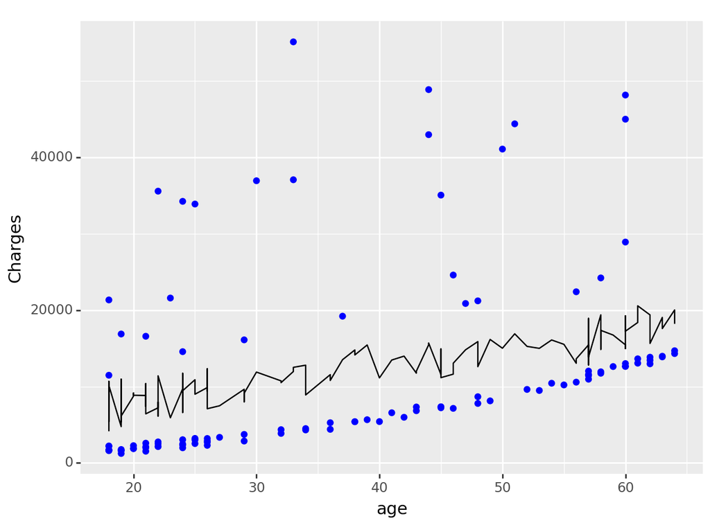

```
<Figure Size: (640 x 480)>
```

```python
X_test['Charges'] = y_test
X_test['Age & BMI'] = age_bmi
X_test['Age degree 2'] = age_age2
X_test['Age degree 4'] = age4
X_test['Age degree 12'] = age12

X_test

plot = (ggplot(X_test, aes(x='age'))
        + geom_point(aes(y='Charges'), color="blue")
        + geom_line(aes(y='Age & BMI'), color = "black")
        )

plot
```

# **Part Four: New data**

For each model, fit the model on the original data.

Then, use the fitted model to predict on the new data.

Report the MSE for each model’s new predictions. Based on this, which is the best model to use?

Make a plot showing the residuals of your final chosen model.

```python
new_insur = pd.read_csv("https://www.dropbox.com/s/sky86agc4s8c6qe/insurance_costs_2.csv?dl=1")
Xnew = new_insur.drop('charges', axis=1)
ynew = new_insur['charges']
```

## Model 1 - only age as predictor

```python
# creating collum tranformer to use only variable age
ct = ColumnTransformer(
  [('untouched_exp_var', pass_variable, ['age'])
  ],
  remainder = "drop"
)

#creating pipeline
lr_pipe = Pipeline(
    [('preprocessing', ct),
        ('linear_reg', LinearRegression())]
)


fitted_lr_pipe = lr_pipe.fit(X,y)


y_preds = fitted_lr_pipe.predict(Xnew)

r2_part31 = r2_score(ynew, y_preds)
mse_part31 = mean_squared_error(ynew, y_preds)
```

## Model 2 - age and bmi as predictors

```python
ct = ColumnTransformer(
  [('untouched_exp_var', pass_variable, ['age','bmi'])
  ],
  remainder = "drop"
)

#creating pipeline
lr_pipe = Pipeline(
    [('preprocessing', ct),
        ('linear_reg', LinearRegression())]
)


fitted_lr_pipe = lr_pipe.fit(X,y)


y_preds = fitted_lr_pipe.predict(Xnew)

r2_part32 = r2_score(ynew, y_preds)
mse_part32 = mean_squared_error(ynew, y_preds)
```

## Model 3 - age, bmi and smoker as predictors

```python
ct = ColumnTransformer(
  [('untouched_exp_var', pass_variable, ['age','bmi']),
   ("dummify", OneHotEncoder(), ['smoker'])
  ],
  remainder = "drop"
)

#creating pipeline
lr_pipe = Pipeline(
    [('preprocessing', ct),
        ('linear_reg', LinearRegression())]
)


fitted_lr_pipe = lr_pipe.fit(X,y)


y_preds = fitted_lr_pipe.predict(Xnew)

r2_part33 = r2_score(ynew, y_preds)
mse_part33 = mean_squared_error(ynew, y_preds)
```

## Model 4 - age and bmi with both interaction with smoker

```python
ct_dummies = ColumnTransformer(
  [("dummify", OneHotEncoder(sparse_output = False), ["smoker"])],
  remainder = "passthrough"
).set_output(transform = "pandas")


ct = ColumnTransformer(
  [('untouched_exp_var', pass_variable, ['remainder__age','remainder__bmi']),
   ("interaction", PolynomialFeatures(interaction_only = True), ["remainder__age", "dummify__smoker_yes"]),
   ("interaction2", PolynomialFeatures(interaction_only = True), ["remainder__bmi", "dummify__smoker_yes"])
  ],
  remainder = "drop"
)

#creating pipeline
lr_pipe = Pipeline(
    [('preprocessing1', ct_dummies),
     ('preprocessing2', ct),
        ('linear_reg', LinearRegression())]
)


fitted_lr_pipe = lr_pipe.fit(X,y)


y_preds4 = fitted_lr_pipe.predict(Xnew)

r2_part34 = r2_score(ynew, y_preds4)
mse_part34 = mean_squared_error(ynew, y_preds4)
```

```python
ct_dummies = ColumnTransformer(
  [("dummify", OneHotEncoder(sparse_output = False), ["smoker"])],
  remainder = "passthrough"
).set_output(transform = "pandas")


ct = ColumnTransformer(
  [('untouched_exp_var', pass_variable, ['remainder__age','remainder__bmi','dummify__smoker_yes']),
   ("dummify2", OneHotEncoder(), ['remainder__region']),
   ("interaction", PolynomialFeatures(interaction_only = True), ["remainder__age", "dummify__smoker_yes"]),
   ("interaction2", PolynomialFeatures(interaction_only = True), ["remainder__bmi", "dummify__smoker_yes"])
  ],
  remainder = "drop"
)

#creating pipeline
lr_pipe = Pipeline(
    [('preprocessing1', ct_dummies),
     ('preprocessing2', ct),
        ('linear_reg', LinearRegression())]
)


fitted_lr_pipe = lr_pipe.fit(X,y)


y_preds = fitted_lr_pipe.predict(Xnew)

r2_part35 = r2_score(ynew, y_preds)
mse_part35 = mean_squared_error(ynew, y_preds)
```

## MSE and R2

```python
table3 = pd.DataFrame({
    'Model': ['Model Q1', 'Model Q2','Model Q3', 'Model Q4', 'Model Q5'],
    'R^2 Score': [r2_part31, r2_part32, r2_part33, r2_part34, r2_part35],
    'MSE': [mse_part31, mse_part32, mse_part33, mse_part34, mse_part35]
})

table3
```

|  | Model | R^2 Score | MSE |
| --- | --- | --- | --- |
| 0 | Model Q1 | 0.12 | 136077136.50 |
| 1 | Model Q2 | 0.14 | 132636406.11 |
| 2 | Model Q3 | 0.77 | 35377541.24 |
| 3 | Model Q4 | 0.86 | 21732073.13 |
| 4 | Model Q5 | 0.85 | 22487873.44 |

Based on mse, the best model to use is moddel from question 4, with age and bmi both interacting with whether the person smokes or not.

## Plot of best model - model 4

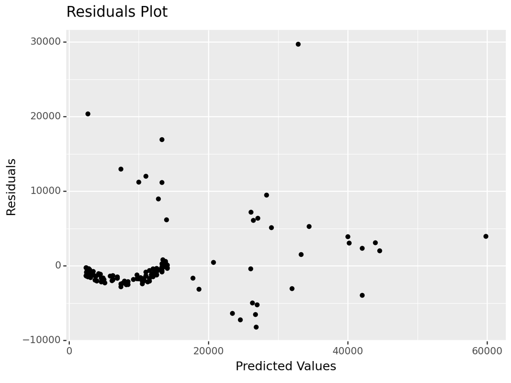

```
<Figure Size: (640 x 480)>
```

```python
residuals = ynew - y_preds4

residuals_df = pd.DataFrame({
    'Predicted': y_preds4,
    'Residuals': residuals
})


residual_plot = (
    ggplot(residuals_df, aes(x='Predicted', y='Residuals')) +
    geom_point() +
    labs(x='Predicted Values', y='Residuals', title='Residuals Plot')
)

residual_plot
```

# **Part Five: Full Exploration**

Using any variables in this dataset, and any polynomial of those variables, find the model that best predicts on the new data after being fit on the original data.

Make a plot showing the residuals of your final chosen model.

```python
ct_dummies = ColumnTransformer(
  [("dummify", OneHotEncoder(sparse_output = False), ["smoker"])],
  remainder = "passthrough"
).set_output(transform = "pandas")


ct = ColumnTransformer(
  [('untouched_exp_var', pass_variable, ['remainder__bmi','dummify__smoker_yes']),
   ("interaction2", PolynomialFeatures(interaction_only = True), ["remainder__bmi", "dummify__smoker_yes"]),
   ('polynmial3', PolynomialFeatures((1,3)), ['remainder__age'])
  ],
  remainder = "drop"
)

#creating pipeline
lr_pipe = Pipeline(
    [('preprocessing1', ct_dummies),
     ('preprocessing2', ct),
        ('linear_reg', LinearRegression())]
)


fitted_lr_pipe = lr_pipe.fit(X,y)


y_preds_final = fitted_lr_pipe.predict(Xnew)

r2 = r2_score(ynew, y_preds_final)
mse = mean_squared_error(ynew, y_preds_final)

r2, mse
```

```
(0.8614425035775972, 21483316.779372808)
```

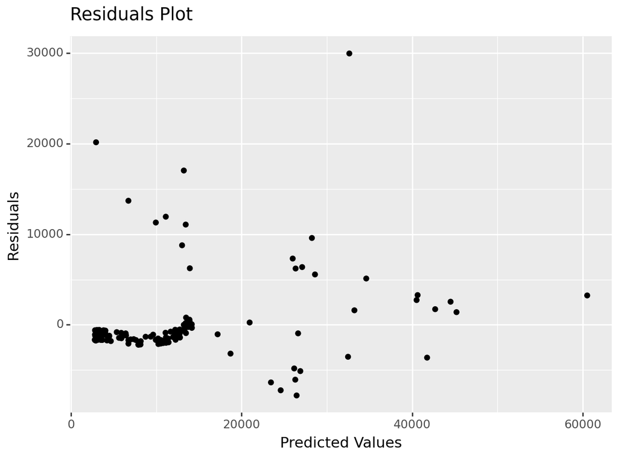

```
<Figure Size: (640 x 480)>
```

```python
residuals_final = ynew - y_preds_final

residuals_final_df = pd.DataFrame({
    'Predicted': y_preds_final,
    'Residuals': residuals_final
})


residual_plot = (
    ggplot(residuals_final_df, aes(x='Predicted', y='Residuals')) +
    geom_point() +
    labs(x='Predicted Values', y='Residuals', title='Residuals Plot')
)

residual_plot
```